# Part II - (Impact of Loan Characteristics on Borrower's APR)

## by (Awurigwe Joseph)

## Investigation Overview

In my inquiry, I sought to look at the characteristics of loans that could be used to predict their borrower APR. The main focus was on the original loan amount, borrower's Prosper rating, loan length, borrower's claimed monthly income.

## Dataset Overview

The dataset comprised of borrower APRs and attributes of 113,937 loans. The attributes included original loan amount, borrower's Prosper rating, loan length, borrower's reported monthly income, as well as many additional features such as borrower's employment status, debt to income ratio, current loan status etc. Many data points were eliminated from the analysis owing to very large claimed monthly income considered as outliers and missing borrower APR information.

## Distribution of Borrower APR

The distribution of APR looks multimodal. A small peak centered at 0.1, a large peak centered at 0.2. There is also a small peak centered 0.3. Additionally, there is a very shape peak between 0.35 and 0.36. Only very few loans have APR greater than 0.42.

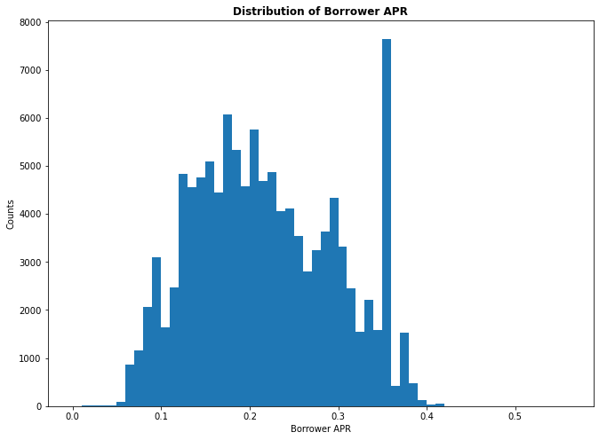

## Distribution of Original Loan Amount

The very large spikes in frequency are at 10000, 15000, 20000, 25000, and 35000. There are also small spikes at 8000, 9000, 11000, 12000, 13000, 140000 etc. It means that most of the loans are multiples of 1000.

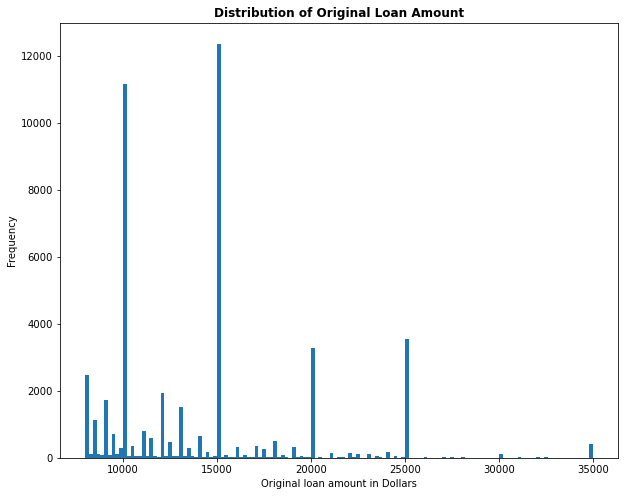

## Borrower APR vs. Loan Amount

At different size of the loan amount, the APR has a large range, but the range of APR decrease with the increase of loan amount. Overall, the borrower APR decrease with increase of loan amount

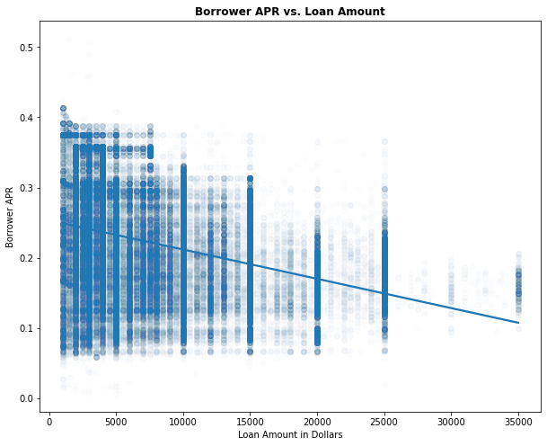

## Prosper Rating Effect on Relationship between APR and Loan Amount

A higher rating raises the loan amount. A better rating lowers the borrower APR. It's interesting to note that as Prosper ratings rise from HR to A or higher, the correlation between borrower APR and loan amount changes from being negatively to marginally positively. This may be so because borrowers with A or AA ratings frequently borrow more money; a higher APR would deter them from doing so and increase the lender's profit. However, because people with poorer credit tend to borrow less money, a lower APR might persuade them to do so.

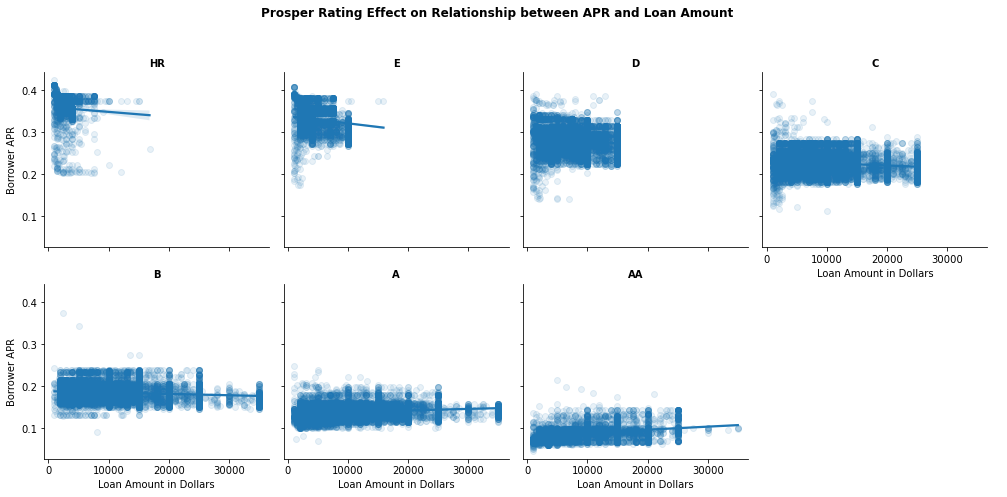

## Borrower APR by Rating and Term

It's interesting to note that for borrowers with HR-C rates, the borrower APR decreases as the borrow period lengthens. However, the APR rises as the length of the loan increases for borrowers with B-AA grades.

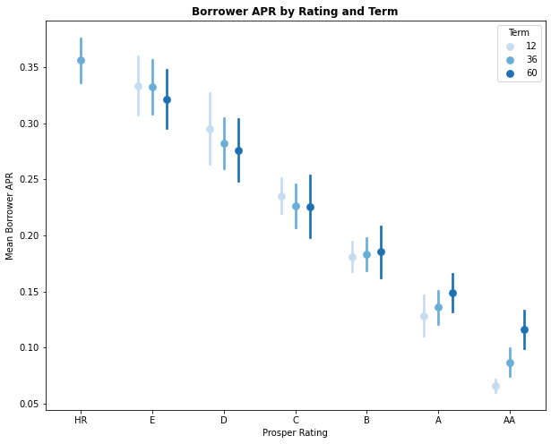